# Advanced Social Media Analysis Project

### 4.4. Hastag Analysis

A word can be considerate as un Hastag if it begins with “#”

```r
signature_hashtag5g <- regexpr("^#[[:alnum:]_]*",all_words5g)
```

```r
list_hashtag5g <- regmatches(all_words5g,signature_hashtag5g)
```

```r
print(length(list_hashtag5g))
```

```
## [1] 1771
```

Frenquency of hastags

```r
nb_hashtags5g <- table(list_hashtag5g)
sort_nb_hashtags5g <- sort(nb_hashtags5g,decreasing=TRUE)
```

Displayed of the 10 most frequent hastags

```r
hash5g = print(sort_nb_hashtags5g[1:10])
```

```
## list_hashtag5g
##               #5g #touscomplotistes          #covid19      #noussachons
##               350                27                25                24
##       #transfonum         #internet               #ai        #numerique
##                22                17                14                14
##             #tpmp           #huawei
##                14                13
```

[figure not shown]

```r
barplot(sort(hash5g,decreasing=TRUE),las=2,cex.names=0.7,col="green2", main='Most Active Users - RT included')
```

5G is the most frequent hashtag which is normal considering we use this word to do the extract. One of the most frequent hastag is Touscomplotistes which refers to the scandal related to the vaccine and reinforce the fact that French people are not confortable with the 5G.

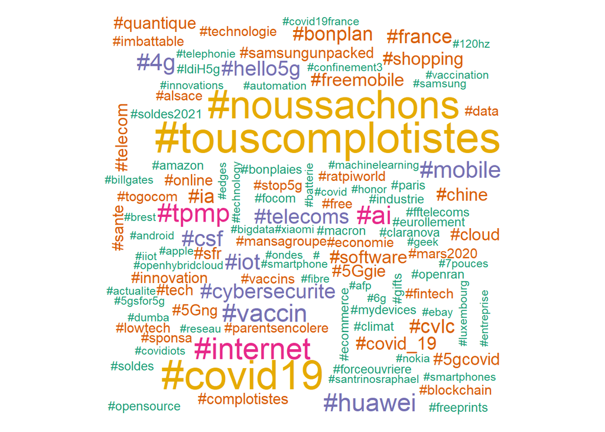

```r
wordcloud(names(sort_nb_hashtags5g)[-1],sort_nb_hashtags5g[-1],scale=c(3,.5),colors=brewer.pal(6, "Dark2"))
```

```r
tags5g<-function(x) toupper(grep("#",strsplit(x," +")[[1]],value=TRUE))
l2 <- nrow(data5G)
taglist5g <- vector(mode = "list", l2)
texts5g <- vector(mode = "character", length = l2)
```

#### Hashtag Network

```r
tags<-function(x) toupper(grep("#",strsplit(x," +")[[1]],value=TRUE))
l <- nrow(data5G)
taglist <- vector(mode = "list", l)
texts <- vector(mode = "character", length = l)

for (i in 1:l) texts[i] <- data5G$text[i]
texts <- iconv(texts, to = "ASCII", sub="")
```

```r
j<-0
for(i in 1:l){
  if(is.na(str_match(texts[i],"#"))[1,1]==FALSE){
    j<-j+1
    taglist[[j]]<-str_squish(removePunctuation(tags(ifelse(is.na(str_match(texts[i], "[\n]")[1,1])==TRUE,texts[i],gsub("[\n]"," ", texts[i])))))
  }
}

alltags <- NULL
for (i in 1:l) alltags<-union(alltags,taglist[[i]])

hash.graph <- graph.empty(directed = T)

hash.graph <- hash.graph + vertices(alltags)

for (tags in taglist){
  if (length(tags)>1){
    for (pair in combn(length(tags),2,simplify=FALSE, FUN=function(x) sort(tags[x]))){
      if (pair[1]!=pair[2]) {
        if (hash.graph[pair[1],pair[2]]==0)
          hash.graph<-hash.graph+edge(pair[1],pair[2])
      }
    }
  }
}
```

```r
V(hash.graph)$color <- "blue"
E(hash.graph)$color <- "black"
V(hash.graph)$name <- paste("#",V(hash.graph)$name, sep = "")
V(hash.graph)$label.cex = 0.75
V(hash.graph)$size <- 12
V(hash.graph)$size2 <- 2
hash.graph_simple<-delete.vertices(simplify(hash.graph),
                                   degree(hash.graph)<=30)
```

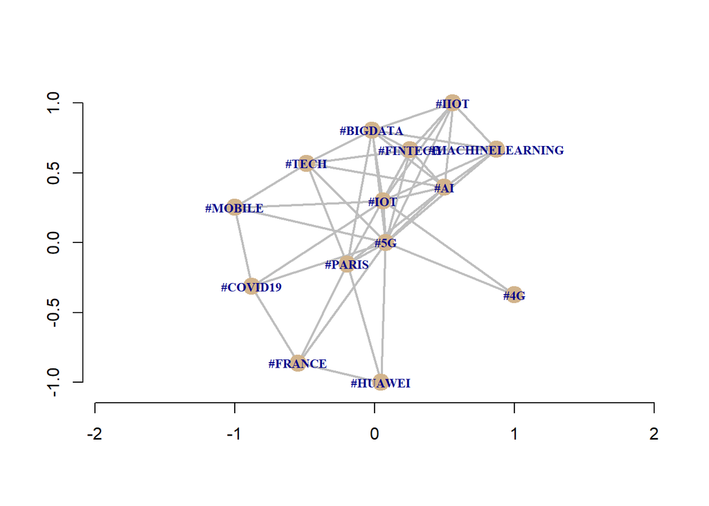

```r
plot(hash.graph_simple, edge.width = 2,
     edge.color = "grey", vertex.color = "tan",
     vertex.frame.color="tan", label.color = "blue",
     vertex.label.font=2, edge.arrow.size=0,5)
```

This 5G network gather a lot of new technlogies such as Machine Learning, IOT, Fintech and AI. But what strick us is that the most correlated hashtags are not the main french operators.

### 4.5 Sentiment analysis

```r
plain.text<-vector()
for(i in 1:dim(data5G)[1]){
  plain.text[i]<- data5g_corpus[[i]][[1]]
}
```

```r
sentence_sentiment<-sentiment(get_sentences(plain.text))
sentence_sentiment
```

```
##       element_id sentence_id word_count   sentiment
##    1:          1           1         23 -0.10425721
##    2:          2           1         17  0.00000000
##    3:          3           1          7  0.00000000
##    4:          4           1         20  0.00000000
##    5:          5           1         22  0.00000000
##   ---
## 4996:       4996           1         21 -0.05455447
## 4997:       4997           1         11  0.22613351
## 4998:       4998           1          9  0.00000000
## 4999:       4999           1          4  0.00000000
## 5000:       5000           1          9  0.00000000
```

```r
average_sentiment<-mean(sentence_sentiment$sentiment)
average_sentiment
```

```
## [1] 0.02212144
```

Surprisingly, the sentiment score is positive despite all the doubts and fear about this technology.

```r
extract_sentiment_terms(get_sentences(plain.text))
```

```
##       element_id sentence_id  negative positive
##    1:          1           1 offensive
##    2:          2           1
##    3:          3           1
##    4:          4           1
##    5:          5           1
##   ---
## 4996:       4996           1     limit
## 4997:       4997           1               cool
## 4998:       4998           1
## 4999:       4999           1
## 5000:       5000           1
```

### 4.6 Topic Modeling

```r
text_corpus2<-text_corpus5g[1:200]
doc.lengths<-rowSums(as.matrix(DocumentTermMatrix(text_corpus2)))
dtm <- DocumentTermMatrix(text_corpus2[doc.lengths > 0])
```

```r
SEED = sample(1:1000000, 1)
```

```r
k = 2
Topics_results<-LDA(dtm, k = k, control = list(seed = SEED))
```

```r
terms(Topics_results,15)
```

```
##       Topic 1          Topic 2
##  [1,] "tlphones"       "numrique"
##  [2,] "tpmp"           "transfonum"
##  [3,] "ondes"          "free"
##  [4,] "arazi"          "aussi"
##  [5,] "marc"           "orange"
##  [6,] "plan"           "rseau"
##  [7,] "gouvernementfr" "francerelance"
##  [8,] "applications"   "rseaux"
##  [9,] "dveloppement"   "amp"
## [10,] "comptitivit"    "merci"
## [11,] "industrielle"   "aprs"
## [12,] "francerelance"  "sfr"
## [13,] "acclrer"        "vaccin"
## [14,] "claire"         "cedrico"
## [15,] "dterminant"     "dacclration"
```

```r
topics(Topics_results)
```

```
##   1   2   3   4   5   6   7   8   9  10  11  12  13  14  15  16  17  18  19  20
##   1   1   1   2   2   2   2   1   2   2   1   2   2   1   2   2   1   2   1   2
##  21  22  23  24  25  26  27  28  29  30  31  32  33  34  35  36  37  38  39  40
##   2   1   1   2   1   1   2   1   2   2   1   2   2   2   2   1   2   2   2   2
##  41  42  43  44  45  46  47  48  49  50  51  52  53  54  55  56  57  58  59  60
##   2   2   2   2   2   1   1   1   2   2   2   1   2   2   1   1   1   1   1   1
##  61  62  63  64  65  66  67  68  69  70  71  72  73  74  75  76  77  78  79  80
##   2   1   2   2   2   2   1   1   2   2   1   1   2   1   2   1   2   1   2   2
##  81  82  83  84  85  86  87  88  89  90  91  92  93  94  95  96  97  98  99 100
##   1   1   1   1   2   2   2   2   2   1   1   2   2   2   1   1   1   2   2   2
## 101 102 103 104 105 106 107 108 109 110 111 112 113 114 115 116 117 118 119 120
##   1   1   1   2   2   1   1   1   1   1   1   1   1   2   2   1   2   1   1   1
## 121 122 123 124 125 126 127 128 129 130 131 132 133 134 135 136 137 138 139 140
##   1   1   1   2   1   2   1   1   2   2   1   1   1   2   2   2   2   2   2   1
## 141 142 143 144 145 146 147 148 149 150 151 152 153 154 155 156 157 158 159 160
##   2   1   2   1   2   1   2   1   2   2   2   1   2   1   1   1   2   1   1   1
## 161 162 163 164 165 166 167 168 169 170 171 172 173 174 175 176 177 178 179 180
##   1   2   1   2   1   1   2   2   1   2   2   1   2   2   1   2   1   1   1   2
## 181 182 183 184 185 186 187 188 189 190 191 192 193 194 195 196 197 198 199 200
##   2   1   2   2   1   2   2   1   1   1   1   1   1   1   2   2   1   1   1   2
```

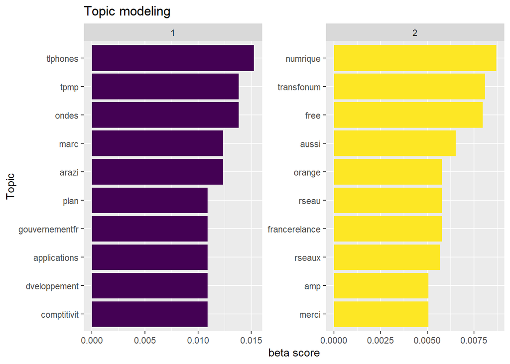

```r
tidy_model_beta<-tidy(Topics_results, matrix = "beta")
tidy_model_beta %>%
  group_by(topic) %>%
  top_n(10, beta) %>%
  ungroup() %>%
  arrange(topic, -beta) %>%
  ggplot(aes(reorder(term, beta),beta,fill=factor(topic)))+
  geom_col(show.legend = FALSE) +
  facet_wrap(~ topic, scales = "free") +
  scale_fill_viridis_d() +
  coord_flip() +
  labs(x = "Topic",
       y = "beta score",
       title = "Topic modeling")
```

## 5. Business Conclusion

For both operators the hastag 5G is the first mentionned, so we can see that the 5G is part and parcel of their communication strategy.

When we talk about 5G, the subject is not directly link to the french operators but mostly about the main controversial topics such as the impact of the 5G on Covid-19 vaccined people, the fear of French people of the dangerous wave the 5G can generate. On the other hand, the operators made the 5G the most popular subject of their twitter communication and marketing campaigns strategy.

The operators should adjust their communication in order to reassure the population. To adopt this new offer the consumer should first feel confident and safe toward his health.

Regarding the drawbacks of the analysis, we can say that our work was focused on twitter results, but the issue is that the operators usually use this social media as after sales customer services, so a huge part of the tweets listed are answers to dissatisfied clients. Moreover, for the same reasons the sentiment analysis is not really relevant regarding the high number of answers to clients.

On the whole, the population keep being skeptical no matter the new advertising campaign, so we can wonder if the french people are really ready to this king of advanced new technology?